# Disease Forecasting

Felipe Dalla Lana; Mladen Cucak; Mauricio Serrano; Paul Esker, Miranda DePriest

## **Introduction**

Now we will learn about disease forecasting and decision support systems. Many different tools are used in disease forecasting, so this lesson will use a generic system where disease infection rate is conditional on a combination of temperature, rainfall, and previous level of infection.

## **Unconditional disease progress**

First, we will cover an example where the rate of disease progress is unconditional. This means that the rate of infection is not dependent of any weather parameters. In this example, the disease will always progress at the same rate.

In the next chunk of code, we will 1) load in the necessary packages, 2) create and transform our data, 3) use a for loop to simulate disease progression through time, and 4) visualize the disease progress.

```r
# Load necessary packages
library("tidyverse") # For data manipulation
library("purrr") # For simulations
library("patchwork") # For plotting

# Create data - a 10 x 1 matrix where week and infection level are columns
data1 <- data.frame(week = c(1:10),
                    inf1 = c(1, rep(0,9)))
data1
```

```
##    week inf1
## 1     1    1
## 2     2    0
## 3     3    0
## 4     4    0
## 5     5    0
## 6     6    0
## 7     7    0
## 8     8    0
## 9     9    0
## 10   10    0
```

```r
# Set the rate of infection to 1
r1 <- 1

# Use a for loop to simulate infection over 9 weeks based on the logistic growth model (covered in Lesson X):

# For weeks 2 through 10
for (j in 2:10){

    # Calculate infection in jth week using the infection level in the previous week and the rate of infection
  data1$inf1[j] <- data1$inf1[(j-1)] * (1 + r1 * (1-data1$inf1[(j-1)]/100))
}
data1
```

```
##    week      inf1
## 1     1  1.000000
## 2     2  1.990000
## 3     3  3.940399
## 4     4  7.725531
## 5     5 14.854223
## 6     6 27.501966
## 7     7 47.440351
## 8     8 72.374833
## 9     9 92.368502
## 10   10 99.417602
```

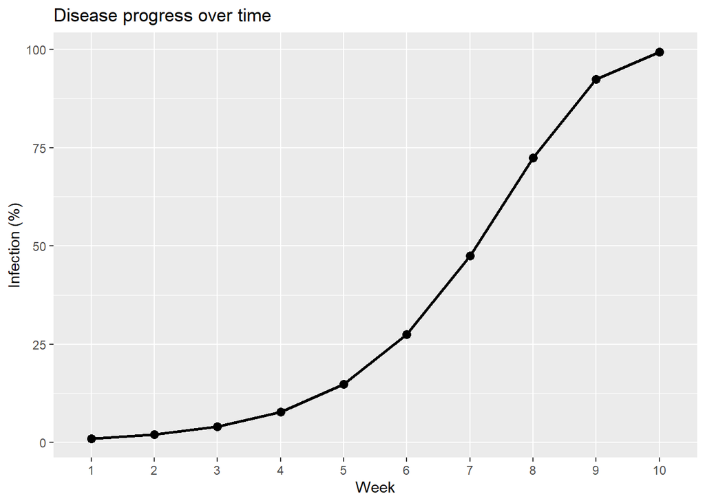

```r
# Coerce data1$week into a factor class, then pass it to ggplot()
data1 %>% mutate(week = as.factor(week)) %>%

  # Plot infection percentage by week
  ggplot(aes(x = week, y = inf1, group = 1)) +
    geom_point(shape = 21, color = "white", fill = "black", size = 3) +
    geom_line(linewidth = 1) +
    labs(y = "Infection (%)", x = "Week",
    title = "Disease progress over time")
```

We have now modeled a simple case where disease progress is unconditional on environmental parameters, and visualized its progress over time. This shows the basics of how disease forecasting can be used to predict what will happen in the future.

## **Disease progress dependent on specific weather parameters**

Now we will explore an example where disease progress is dependent on specific weather conditions. In this example, rainfall and temperature will influence our disease progression. To simplify this example, only the *occurrence* of rainfall will be recorded for a week, rather than the amount, with a binomial distribution. In this case, a value of 1 will indicate that rainfall did occur, and 0 will indicate that it did not. Temperature values will be generated using a normal distribution centered around 20°C.

In the next chunk of code, we will generate random but reproducible data for rainfall and temperature and visualize both environmental variables over time.

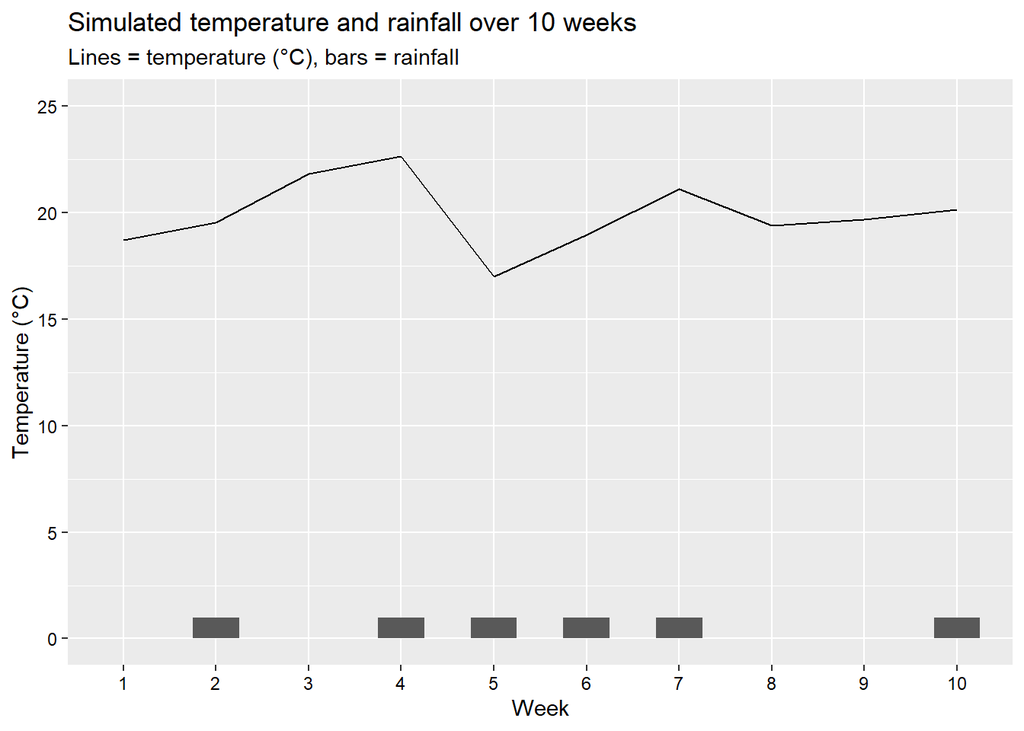

```r
# Define a pseudorandom value to ensure reproducibility
set.seed(441909)

# Create the example weather data
weather <- data.frame(week = 1:10,
                    rain = rbinom(n = 10, size = 1, prob = 0.5),
                    temp = 20 + rnorm(n = 10, mean = 0, sd = 2))

# Coerce week values into factor class and pass the data along to be visualized with a pipe (%>%)
weather %>%
  mutate(week = factor(week)) %>%
  ggplot(aes(x = week, group = 1)) +
  geom_line(aes(y = temp)) + # Represent temperature with a line
  geom_col(aes(y = rain), width = 0.5) + # Represent rainfall with a bar
  scale_y_continuous(limits = c(0,25), breaks = seq(0,25,5)) +
  labs(title = "Simulated temperature and rainfall over 10 weeks",
       subtitle = "Lines = temperature (°C), bars = rainfall",
       y = "Temperature (°C)",
       x = "Week") +
       theme(axis.text = element_text(color = "black"))
```

Now we can move on to the disease progression data. In this example, disease progression requires the occurrence of rainfall. Furthermore, the progression of the disease is highest at temperatures above 20°C, and reduced at temperatures below 20°C.

In this chunk of code, we will use rainfall and temperature to determine the rate of disease progression (r2), and the percentage of disease (inf).

```r
# Manipulate weather data to create r2 and create a column for inf
data2 <-
  weather %>%
  mutate(r2 = r1 * rain * (1 + (temp - 20)/20)) %>%
  mutate(inf2 =  c(1, rep(0,9)))
data2
```

```
##    week rain     temp        r2 inf2
## 1     1    0 18.71620 0.0000000    1
## 2     2    1 19.53240 0.9766200    0
## 3     3    0 21.84324 0.0000000    0
## 4     4    1 22.66552 1.1332762    0
## 5     5    1 17.00063 0.8500317    0
## 6     6    1 18.95757 0.9478784    0
## 7     7    1 21.10934 1.0554672    0
## 8     8    0 19.41075 0.0000000    0
## 9     9    0 19.68195 0.0000000    0
## 10   10    1 20.14318 1.0071589    0
```

```r
# Use a for loop to simulate disease progression
for (j in 2:10) {data2$inf2[j] <- data2$inf2[j-1] *
                    (1 + data2$r2[j-1]*(1 - data2$inf2[j-1]/100))
}
data2
```

```
##    week rain     temp        r2      inf2
## 1     1    0 18.71620 0.0000000  1.000000
## 2     2    1 19.53240 0.9766200  1.000000
## 3     3    0 21.84324 0.0000000  1.966854
## 4     4    1 22.66552 1.1332762  1.966854
## 5     5    1 17.00063 0.8500317  4.152002
## 6     6    1 18.95757 0.9478784  7.534796
## 7     7    1 21.10934 1.0554672 14.138726
## 8     8    0 19.41075 0.0000000 26.951772
## 9     9    0 19.68195 0.0000000 26.951772
## 10   10    1 20.14318 1.0071589 26.951772
```

We can see that the disease progresses more quickly when there is rain and when the temperature is above 20°C. Now we’ll visualize the rate of infection in both scenarios (r1 and r2)

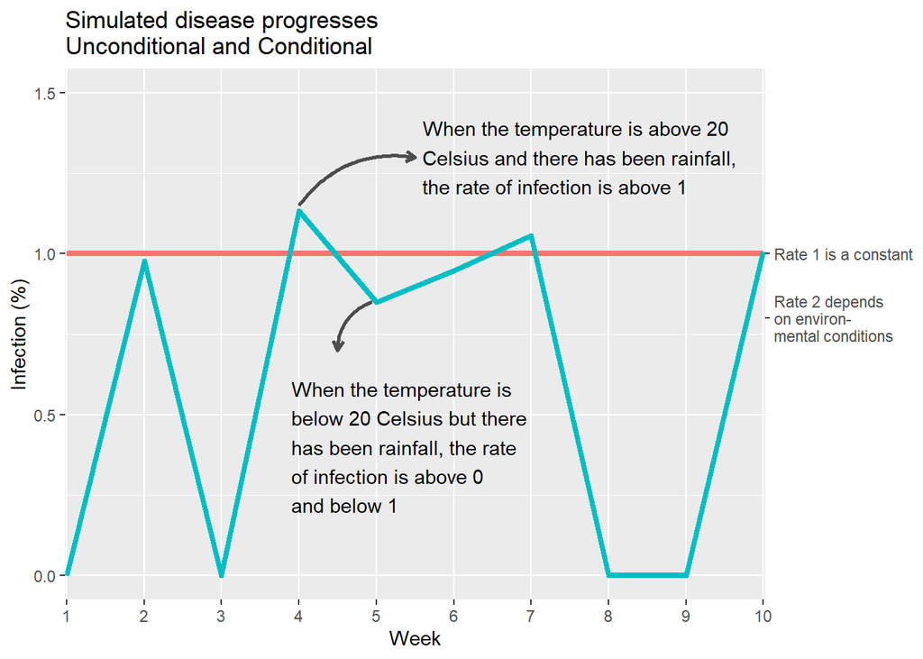

```r
# Merge data1 and data2
rates <- left_join(data1, data2, by = join_by(week)) %>%

  # Set r1 and coerce week to factor class
  mutate(r1 = 1, week = factor(week)) %>%

  # Select only relevant columns
  select(week, inf1, inf2, r1, r2) %>%

  # Transform the data to a longer format where r1 and r2 are in columns
  pivot_longer(.,
               cols = c(r1, r2),
               names_to = "Rate_Perc")

# Plot r1 and r2 over time
ggplot(rates, aes(x = week, y = value, color = Rate_Perc, group = Rate_Perc)) +
  geom_line(linewidth = 1.5) +
  scale_y_continuous(limits = c(0, 1.5),
                     sec.axis = sec_axis(~.*1, breaks = c(1,0.8),
                                         labels = c("Rate 1 is a constant", "Rate 2 depends\non environ-\nmental conditions"))) +
  scale_x_discrete(expand = c(0, 0.02)) +
  labs(x = "Week", y = "Infection (%)",
      title = "Simulated disease progresses\nUnconditional and Conditional") +
  theme(legend.position = "none") +

  # Add the first arrow
  annotate(geom = "curve", x = 4, y = 1.15, xend = 5.5, yend = 1.3, curvature = -0.3, arrow = arrow(length = unit(2, "mm")), size = 1, color = "grey30") +

  # Add a label to the first arrow
  annotate(label = "When the temperature is above 20\nCelsius and there has been rainfall,\nthe rate of infection is above 1",
           geom = "text", x = 5.6, y = 1.3, hjust = "left") +

  # Add the second arrow
  annotate(geom = "curve", x = 4.95, y = 0.85, xend = 4.5, yend = 0.7, curvature = 0.35, arrow = arrow(length = unit(2, "mm")), size = 1, color = "grey30") +

  # Add a label to the second arrow
  annotate(label = "When the temperature is\nbelow 20 Celsius but there\nhas been rainfall, the rate\nof infection is above 0\nand below 1", geom = "text", x = 3.9, y = 0.4, hjust = "left")
```

We’ve seen how the rate of infection changes based on whether infection is influenced by certain environmental variables or not. Now let’s see how the total infection level is impacted.

In the next chunk, we’ll manipulate the data and plot the total infection level (inf1 and inf2) for both scenarios.

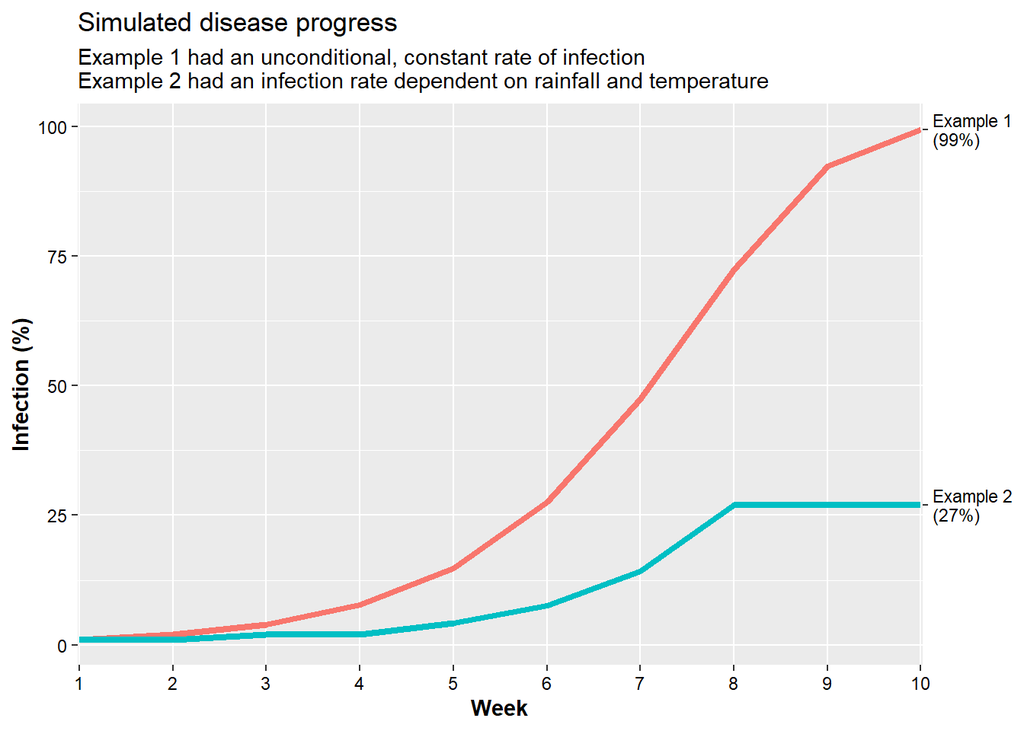

```r
# Merge data1 and data2
infs <- left_join(data1, data2, by = join_by(week)) %>%

  # Set column r1 to be 1 and make the week column into a factor class
  mutate(r1 = 1,
         week = factor(week)) %>%

  # Select
  select(week, inf1, inf2)

# Transform infs into a longer dataframe with inf1 and inf2 values as a column
pivot_longer(infs, cols = c(inf1, inf2),
             names_to = "Inf_Perc") %>%

  # And pass it to ggplot2() for visualization
  ggplot(., aes(x = week, y = value, color = Inf_Perc, group = Inf_Perc)) +
  geom_line(linewidth = 1.5) +
  scale_y_continuous(sec.axis = sec_axis(~.*1,
                                         breaks = c(99.4, 27),
                                         labels = c("Example 1\n(99%)", "Example 2\n(27%)"))) +
  scale_x_discrete(expand = c(0, 0.02)) +
  labs(x = "Week", y = "Infection (%)",
       title = "Simulated disease progress",
       subtitle = "Example 1 had an unconditional, constant rate of infection \nExample 2 had an infection rate dependent on rainfall and temperature") +
  theme(legend.position = "none",
        axis.text = element_text(color = "black"),
        axis.title = element_text(face = "bold"))
```

Now we’ve compared a model with a constant rate of infection to a model with a rate of infection dependent on the weather. Now we’ll move to a more complicated and realistic exercise where weather prediction isn’t perfect.

## **500 simulations of disease progression**

Weather patterns change, influencing the ways in which we can forecast disease development. We will simulate multiple weather scenarios to see how a range of possible environmental conditions impact disease development.

We’ll build on the disease parameters in Example 2. The rate of infection is dependent on rainfall and is optimal at 20°C and above. The difference is that we are going to forecast disease progression for 500 different weather scenarios to see the range of possible outcomes.

In the next chunk of code, we will create a function for the simulation.

```r
# Define 'DiseaseCast' as a function that requires rate of infection, number of weeks to model, the starting disease %, and the probability of rain in a given week
DiseaseCast <- function(rate, nweeks, start, rprob){

  # Create a data frame 'dis.data' with placeholder columns for inf (% infected) and temp, and data for rainfall and week
  dis.data <- data.frame(inf = rep(0, nweeks),
                        rain = rbinom(n = nweeks, size = 1, prob = rprob),
                        temp = rep(0, nweeks),
                        week = 1:nweeks)

  # Fill in the starting % infected and temperature
  dis.data$inf[1] <- start
  dis.data$temp[1] <- 20

  # Use a for loop to simulate the temperature over nweeks
  for (j in 2:nweeks){

    dis.data$temp[j] <- dis.data$temp[j-1] + rnorm(n = 1, mean = 0, sd = 2)
  }

  # Transform dis.data to produce rates of infection dependent on rain and temp. Use an if_else statement to avoid problems with negative temp
  dis.data <- mutate(dis.data,
                    temp = if_else(temp < 0, 0, temp)) %>%
    mutate(rate = rate * rain * (1 + (temp - 20)/20))

  # Calculate the % of infection over time
  for (j in 2:10){

  # Calculate the % infected using an if_else statement to avoid scenarios where the total % infected is 100% or above
    dis.data$inf[j] <- dis.data$inf[j-1] * (1 + dis.data$rate[j-1]) * (1 - (if_else(dis.data$inf[j-1] >= 100, 1, dis.data$inf[j-1]/100)))

  # Mutate dis.data to have a column for the week, and to avoid adding % infected values of 100% or more
  dis.data <- mutate(dis.data,
                    week = 1:nweeks,
                    inf = if_else(inf >= 100, 100, inf))
  }

  # Return the data frame object
  dis.data
}
```

Now we have a custom function that will allow us to quickly model scenarios. We’ll add components from the `purrr` package to help us quickly run 500 simulations.

```r
# Define the number of simulations
n <- 500

# Create an XX object where every iteration of the simulation is stored
simul_1 <- map(seq_len(n),
               ~DiseaseCast(r = 1, nweeks = 10, start = 1, rprob = 0.5)) %>%

  # Format the resulting object
  map2(., 1:n, ~cbind(.x, RUN = .y)) %>%
  bind_rows()

# Inspect the object
head(simul_1)
```

```
##         inf rain     temp week      rate RUN
## 1  1.000000    1 20.00000    1 1.0000000   1
## 2  1.980000    1 19.16912    2 0.9584559   1
## 3  3.800963    1 20.21277    3 1.0106385   1
## 4  7.351880    1 20.83132    4 1.0415660   1
## 5 13.905879    1 20.03596    5 1.0017981   1
## 6 23.965816    0 18.14891    6 0.0000000   1
```

```r
tail(simul_1)
```

```
##           inf rain     temp week    rate RUN
## 4995 2.013402    0 22.78417    5 0.00000 500
## 4996 1.972864    1 21.21920    6 1.06096 500
## 4997 3.985777    0 22.57731    7 0.00000 500
## 4998 3.826913    0 24.31330    8 0.00000 500
## 4999 3.680460    1 22.35340    9 1.11767 500
## 5000 7.507145    0 21.87583   10 0.00000 500
```

Now we can visualize the outcomes of these 500 simulations to see the range of possible disease progression scenarios. We’ll create two figures. The first will show each simulation’s disease progression trajectory over time, and the second will be a box plot showing the range of final disease states.

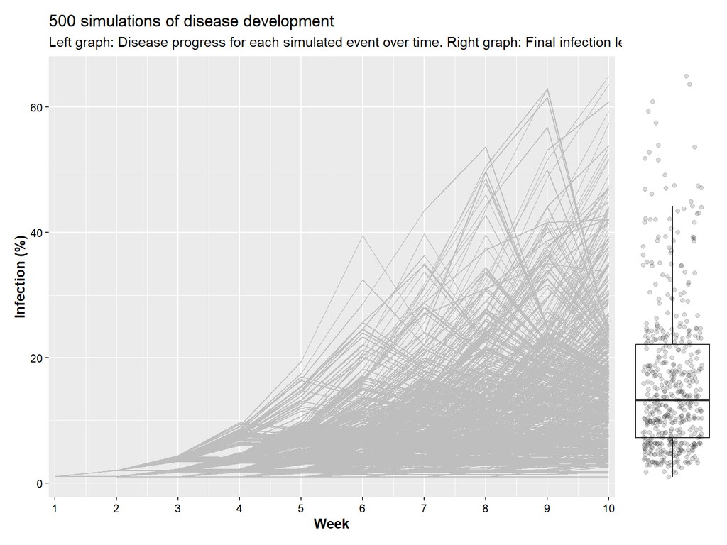

```r
# Create the line plot showing disease trajectory for each simulation
a <- ggplot(simul_1) +
  geom_line(aes(x = week, y = inf, group = RUN, color = RUN), color = "grey") +
  labs(x = "Week", y = "Infection (%)",
       title = "500 simulations of disease development",
       subtitle = "Left graph: Disease progress for each simulated event over time. Right graph: Final infection level (%)") +
  scale_x_continuous(breaks = 1:10, expand = c(0.0, 0.1)) +
  theme(legend.position = "none",
        axis.text = element_text(color = "black"),
        axis.title = element_text(face = "bold"))

# Create the boxplot showing final disease infection level
b <- filter(simul_1, week == 10) %>%
  ggplot(aes(x = week, y = inf)) +
  geom_boxplot(outlier.alpha = 0) +
  geom_jitter(alpha = 0.15, width = 0.3) +
  theme(panel.background = element_blank(),
        axis.title = element_blank(),
        axis.text = element_blank(),
        axis.ticks = element_blank())

# Plot the two parts, a and b, together
a + b + plot_layout(ncol = 2, widths = c(7, 1))
```

Now we’ve seen a range of disease progression outcomes based on 500 simulations with identical parameters, but random outcomes. Now we’ll explore what happens when one of the parameters, the probability of rain, changes.

## **500 simulations of different rain probabilities**

In the next example, we’ll start with all of the same parameters *except* the probability of rain. We’ll create a group of simulations with a 10%, 30%, 50%, 70%, and 90% change of rain.

In the next chunk of code, we’ll create the simulated data for each group. Then, we’ll bind each data set together and filter for Week 10 outcomes.

```r
# 500 simulations of 10% chance of rain
simul_10 <- map(seq_len(n),
                ~DiseaseCast(rate = 1, nweeks = 10, start = 1, rprob = 0.1)) %>%
  map2(., 1:n, ~cbind(.x, RUN = .y)) %>%
  bind_rows() %>%
  mutate(prob = "p10")

# 30% chance of rain
simul_30 <- map(seq_len(n),
                ~DiseaseCast(rate = 1, nweeks = 10, start = 1, rprob = 0.3)) %>%
  map2(., 1:n, ~cbind(.x, RUN = .y)) %>%
  bind_rows() %>%
  mutate(prob = "p30")

# 50% chance of rain
simul_50 <- map(seq_len(n),
                ~DiseaseCast(rate = 1, nweeks = 10, start = 1, rprob = 0.5)) %>%
  map2(., 1:n, ~cbind(.x, RUN = .y)) %>%
  bind_rows() %>%
  mutate(prob = "p50")

# 70% chance of rain
simul_70 <- map(seq_len(n),
                ~DiseaseCast(rate = 1, nweeks = 10, start = 1, rprob = 0.7)) %>%
  map2(., 1:n, ~cbind(.x, RUN = .y)) %>%
  bind_rows() %>%
  mutate(prob = "p70")

# 90% chance of rain
simul_90 <- map(seq_len(n),
                ~DiseaseCast(rate = 1, nweeks = 10, start = 1, rprob = 0.9)) %>%
  map2(., 1:n, ~cbind(.x, RUN = .y)) %>%
  bind_rows() %>%
  mutate(prob = "p90")

# Combine each data set and select for week 10
comb_simul <- bind_rows(simul_10, simul_30, simul_50, simul_70, simul_90) %>% filter(week == 10)
```

Now that we have the simulated data, we can visualize how the outcomes change based on the chance of rain.

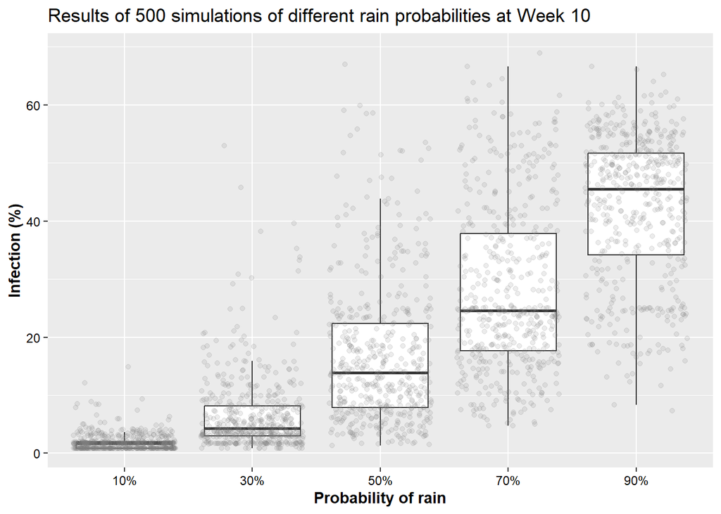

```r
ggplot(comb_simul, aes(x = prob, y = inf)) +
  geom_boxplot(outlier.alpha = 0) +
  geom_jitter(alpha = 0.15, widdth = 0.3, color = "grey50") +
  labs(x = "Probability of rain", y = "Infection (%)",
       title = "Results of 500 simulations of different rain probabilities at Week 10") +
  scale_x_discrete(labels = c("10%", "30%", "50%", "70%", "90%")) +
  theme(legend.position = "none",
        axis.text = element_text(color = "black"),
        axis.title = element_text(face = "bold"))
```

We can see that the probability of rain can have a big influence on the likely outcome of a disease. A majority of the simulations with 10% probability of rain had relatively low disease at Week 10, while those with 90% chance of rain were much higher.

## **500 simulations of different rates of infection**

In the next example, we will explore how the initial rate of infection (r) affects the intensity of the disease at Week 10. Understanding how the initial rate of infection can help us predict different diseases, but it can also help us model the outcomes of different intervention strategies.

In the next chunk of code, we will create data sets with different initial rate of infection. We’ll use rates of infections ranging from 0.25 to 2 at intervals of 0.25.

```r
# Create data for 500 simulations with r = 0.25
simul_0.25 <- map(seq_len(n),
                 ~DiseaseCast(rate = 0.25, nweeks = 10, start = 1, rprob = 0.5)) %>%
                   map2(., 1:n, ~cbind(.x, RUN = .y)) %>%
                   bind_rows() %>%
                   mutate(rate = "r_0.25")

# r = 0.50
simul_0.5 <- map(seq_len(n),
                 ~DiseaseCast(rate = 0.5, nweeks = 10, start = 1, rprob = 0.5)) %>%
                   map2(., 1:n, ~cbind(.x, RUN = .y)) %>%
                   bind_rows() %>%
                   mutate(rate = "r_0.5")

# r = 0.75
simul_0.75 <- map(seq_len(n),
                 ~DiseaseCast(rate = 0.75, nweeks = 10, start = 1, rprob = 0.5)) %>%
                   map2(., 1:n, ~cbind(.x, RUN = .y)) %>%
                   bind_rows() %>%
                   mutate(rate = "r_0.75")

# r = 1.0
simul_1.0 <- map(seq_len(n),
                 ~DiseaseCast(rate = 1.0, nweeks = 10, start = 1, rprob = 0.5)) %>%
                   map2(., 1:n, ~cbind(.x, RUN = .y)) %>%
                   bind_rows() %>%
                   mutate(rate = "r_1.0")

# r = 1.25
simul_1.25 <- map(seq_len(n),
                 ~DiseaseCast(rate = 1.25, nweeks = 10, start = 1, rprob = 0.5)) %>%
                   map2(., 1:n, ~cbind(.x, RUN = .y)) %>%
                   bind_rows() %>%
                   mutate(rate = "r_1.25")

# r = 1.5
simul_1.5 <- map(seq_len(n),
                 ~DiseaseCast(rate = 1.5, nweeks = 10, start = 1, rprob = 0.5)) %>%
                   map2(., 1:n, ~cbind(.x, RUN = .y)) %>%
                   bind_rows() %>%
                   mutate(rate = "r_1.5")

# r = 1.75
simul_1.75 <- map(seq_len(n),
                 ~DiseaseCast(rate = 1.75, nweeks = 10, start = 1, rprob = 0.5)) %>%
                   map2(., 1:n, ~cbind(.x, RUN = .y)) %>%
                   bind_rows() %>%
                   mutate(rate = "r_1.75")

# r = 2.0
simul_2.0 <- map(seq_len(n),
                 ~DiseaseCast(rate = 2.0, nweeks = 10, start = 1, rprob = 0.5)) %>%
                   map2(., 1:n, ~cbind(.x, RUN = .y)) %>%
                   bind_rows() %>%
                   mutate(rate = "r_2.0")
```

Now we’ll combine each of these data sets and plot the disease outcome at Week 10 like we did in the previous example.

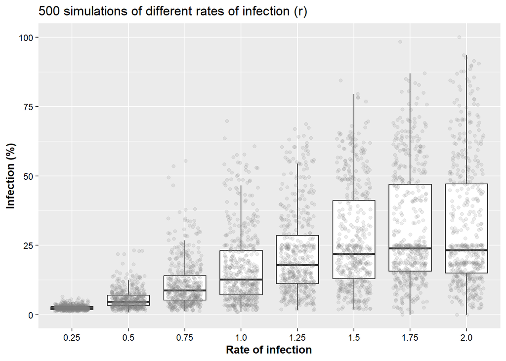

```r
# Combine each data set
comb_simul <- bind_rows(simul_0.25, simul_0.5, simul_0.75, simul_1.0,
                        simul_1.25, simul_1.5, simul_1.75, simul_2.0) %>%
  filter(week == 10)

# Plot
ggplot(comb_simul, aes(x = rate, y = inf)) +
  geom_boxplot(outlier.alpha = 0) +
  geom_jitter(alpha = 0.15, width = 0.3, color = "grey50") +
  labs(x = "Rate of infection", y = "Infection (%)",
       title = "500 simulations of different rates of infection (r)") +
  scale_x_discrete(labels = c("0.25", "0.5", "0.75", "1.0", "1.25", "1.5", "1.75", "2.0")) +
  theme(legend.position = "none",
        axis.text = element_text(color = "black"),
        axis.title = element_text(face = "bold"))
```

## **Considering intervention**

We will now consider the forecasting models we’ve been working with as support systems. When diseases occur, it can be helpful to model how certain interventions, such as fungicides, may help the situation. In this case, the interventions we will model don’t heal infected plants, but they do prevent new infections.

In the example we will consider, the model is simple. When the predicted number of infected plants is above a certain threshold, we will use an intervention to reduce the disease to 10% of its potential level.

```r
# Define InterventionCast()
InterventionCast <- function(rate, nweeks, start, rprob, threshold, action){

  # Create data frame with placeholder columns for week, rain, temp, % infected, and action taken
  dis.data <- data.frame(week = 1:nweeks,
                         rain = rbinom(n = nweeks, size = 1, prob = rprob),
                         temp = c(20, rep(0, (nweeks-1))),
                         inf = c(1, rep(0, (nweeks - 1))))

  # Populate dis.data$temp with temperature data
  for (j in 2:nweeks){

    # The current week's temp is dependent on previous week's temp
    dis.data$temp[j] <- dis.data$temp[j-1] + rnorm(n = 1, mean = 0, sd = 2)
  }

  # Replace any negative temp values with 0 and pass dis.data on
  dis.data <- mutate(dis.data, temp = if_else(temp < 0, 0, temp)) %>%

    # Calculate the rate (dependent on temp and rain) for each week
    mutate(rate = rate * rain * (1 + (temp - 20)/20))

  # Calculate the % infected
  for (j in 2:nweeks){

    # IF the previous % infected is above 30% AND we are considering intervention, rate is 1/10th what it would be
    if (dis.data$inf[j-1] > threshold & action){

      # The new rate of infection is 1/10th what it would be
      r <- 0.1 * dis.data$rate[j-1]

      # If not...
    } else {

      # We use the same rate of spread, dependent only on rain and temp
      r <- dis.data$rate[j-1]
    }

    # The % infected is dependent on the previous % infected and whichever rate of spread is appropriate
      dis.data$inf[j] <- dis.data$inf[j-1] * (1 + r) * (1 - (if_else(dis.data$inf[j-1] >= 100, 1, dis.data$inf[j-1]/100)))
  }

  # Return the data frame
  dis.data
}
```

Now we will use `InterventionCast()` to run 500 simulations for disease progression when intervention is considered and when it is not.

```r
# Create data for 500 simulations when intervention is considered
simul_int <- map(seq_len(n),
                 ~InterventionCast(rate = 1, nweeks = 10, rprob = 0.5, threshold = 30, action = TRUE)) %>%
  map2(., 1:n, ~cbind(.x, RUN = .y)) %>%
  bind_rows()

# When intervention is not considered
simul_no.int <- map(seq_len(n),
                 ~InterventionCast(rate = 1, nweeks = 10, rprob = 0.5, threshold = 30, action = FALSE)) %>%
  map2(., 1:n, ~cbind(.x, RUN = .y)) %>%
  bind_rows()
```

We will now visualize the results for both groups of simulations.

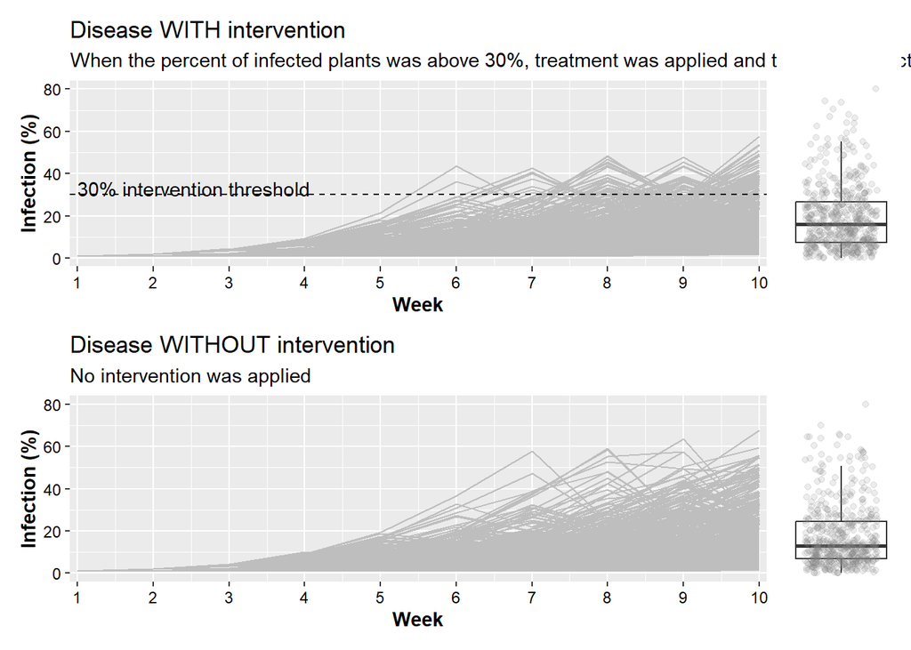

```r
# Create a plot for the disease trajectory over time for the group WITH intervention
int.tra <- ggplot(simul_int) +
  geom_line(aes(x = week, y = inf, color = RUN, group = RUN), color = "grey") +
    geom_hline(aes(yintercept = 30), linetype = "dashed") +
  labs(x = "Week", y = "Infection (%)",
       title = "Disease WITH intervention",
       subtitle = "When the percent of infected plants was above 30%, treatment was applied and the rate of infection was decreased to 1/10th") +
  scale_x_continuous(breaks = 1:10, expand = c(0.0, 0.1)) +
    ylim(0,80) +
 theme(legend.position = "none",
        axis.text = element_text(color = "black"),
        axis.title = element_text(face = "bold")) +
        annotate(label = "30% intervention threshold",
                 geom = "text", x = 1, y = 33, hjust = "left")

# Create a boxplot for the final % infected WITH intervention
int.box <- filter(simul_int, week == 10) %>%
  ggplot(aes(x = week, y = inf)) +
  geom_boxplot(outlier.alpha = 0) +
  geom_jitter(alpha = 0.15, width = 0.3, color = "grey50") +
  theme(panel.background = element_blank(),
        axis.title = element_blank(),
        axis.text = element_blank(),
        axis.ticks = element_blank())

# Create a plot for the disease trajectory over time for the group WITHOUT intervention
no.int.tra <- ggplot(simul_no.int) +
  geom_line(aes(x = week, y = inf, color = RUN, group = RUN), color = "grey") +
  labs(x = "Week", y = "Infection (%)",
       title = "Disease WITHOUT intervention",
       subtitle = "No intervention was applied") +
  scale_x_continuous(breaks = 1:10, expand = c(0.0, 0.1)) +
  theme(legend.position = "none",
        axis.text = element_text(color = "black"),
        axis.title = element_text(face = "bold")) +
  ylim(0,80)

# Create a boxplot for the final % infected WITHOUT intervention
no.int.box <- filter(simul_no.int, week == 10) %>%
  ggplot(aes(x = week, y = inf)) +
  geom_boxplot(outlier.alpha = 0) +
  geom_jitter(alpha = 0.15, width = 0.3, color = "grey50") +
  theme(panel.background = element_blank(),
        axis.title = element_blank(),
        axis.text = element_blank(),
        axis.ticks = element_blank())

# Plot all four plot items
int.tra + int.box + no.int.tra + no.int.box +
  plot_layout(ncol = 2, nrow = 2, widths = c(7, 1, 7, 1))
```

In the plot without intervention, the progression of disease was a function of weather conditions alone. In the plots where intervention was used, we can see that disease progression decreased after the percent infected reached above 30%. Importantly, we can see that these two groups of scenarios did not result in completely different outcomes. When intervention was used, it became rarer for disease development to reach above 60%, but otherwise disease progression was similar.

In the final example, we can visualize what happens when the intervention threshold is changed. We’ll use the same parameters as in the last example except with intervention thresholds of 5, 10, 15, 20, 40, 60, and 80%. To save time, we will only run 100 simulations of each scenario.

```r
# Change n, the number of simulations to run
n = 100

# Run 100 simulations with threshold = 5
simul_05 <- map(seq_len(n),
                ~InterventionCast(rate = 1, nweeks = 10, start = 1, rprob = 0.5, threshold = 5, action = TRUE)) %>%
  map2(., 1:n, ~cbind(.x, RUN = .y)) %>%
  bind_rows() %>%
  mutate(threshold = "5")

# Run 100 simulations with threshold = 10
simul_10 <- map(seq_len(n),
                ~InterventionCast(rate = 1, nweeks = 10, start = 1, rprob = 0.5, threshold = 10, action = TRUE)) %>%
  map2(., 1:n, ~cbind(.x, RUN = .y)) %>%
  bind_rows() %>%
  mutate(threshold = "10")

# Run 100 simulations with threshold = 15
simul_15 <- map(seq_len(n),
                ~InterventionCast(rate = 1, nweeks = 10, start = 1, rprob = 0.5, threshold = 15, action = TRUE)) %>%
  map2(., 1:n, ~cbind(.x, RUN = .y)) %>%
  bind_rows() %>%
  mutate(threshold = "15")

# Run 100 simulations with threshold = 20
simul_20 <- map(seq_len(n),
                ~InterventionCast(rate = 1, nweeks = 10, start = 1, rprob = 0.5, threshold = 20, action = TRUE)) %>%
  map2(., 1:n, ~cbind(.x, RUN = .y)) %>%
  bind_rows() %>%
  mutate(threshold = "20")

# Run 100 simulations with threshold = 40
simul_40 <- map(seq_len(n),
                ~InterventionCast(rate = 1, nweeks = 10, start = 1, rprob = 0.5, threshold = 40, action = TRUE)) %>%
  map2(., 1:n, ~cbind(.x, RUN = .y)) %>%
  bind_rows() %>%
  mutate(threshold = "40")

# Run 100 simulations with threshold = 60
simul_60 <- map(seq_len(n),
                ~InterventionCast(rate = 1, nweeks = 10, start = 1, rprob = 0.5, threshold = 60, action = TRUE)) %>%
  map2(., 1:n, ~cbind(.x, RUN = .y)) %>%
  bind_rows() %>%
  mutate(threshold = "60")

# Run 100 simulations with threshold = 80
simul_80 <- map(seq_len(n),
                ~InterventionCast(rate = 1, nweeks = 10, start = 1, rprob = 0.5, threshold = 80, action = TRUE)) %>%
  map2(., 1:n, ~cbind(.x, RUN = .y)) %>%
  bind_rows() %>%
  mutate(threshold = "80")
```

Now we can visualize the disease outcome at Week 10 for each of the threshold values we’ve simulated.

[figure not shown]

```r
# First, we need to combine each group of simulations (including the group of simulations with no intervention)
simul_thresh <- bind_rows(simul_05, simul_10, simul_15, simul_20, simul_40, simul_60, simul_80, simul_no.int) %>%

  # Then we'll filter for Week 10
  filter(., week == 10)

  # And now we'll plot boxplots for each threshold value
  ggplot(simul_thresh, aes(x = factor(threshold), y = inf, group = threshold)) +
  geom_boxplot(outlier.alpha = 0) +
  geom_jitter(alpha = 0.15, width = 0.3, color = "grey50") +
  labs(x = "Intervention threshold %",
       y = "Infection (%)",
       title = "Final infection level with different intervention thresholds",
       subtitle = "Intervention reduces rate of infection to 10% of its value") +
  scale_x_discrete(labels = c("5%", "10%", "15%", "20%", "40%", "60%", "80%", "No intervention")) + theme(legend.position = "none",
      axis.text = element_text(color = "black"),
      axis.title = element_text(face = "bold"))
```